# Análisis Fintual - Valor Cuota y Riesgo

Fondo Risky Norris

Autor/a

Paulo Villarroel

Fecha de publicación

22 de mayo de 2025

**Código**

```r
library(ggplot2)
library(dplyr)
library(scales)
library(lubridate)
library(gridExtra)
library(knitr)
library(purrr)
```

**Código**

```r
# Cargar datos desde archivo externo
source("api-req.R")

# Verificar que los datos se cargaron correctamente
if (!exists("df") || !is.data.frame(df)) {
  stop("Error: No se pudo cargar el dataframe 'df' desde api-req.R")
}

cat(
  "Período de análisis:",
  format(as.Date(start_date), "%d/%m/%Y"),
  "al",
  format(as.Date(end_date), "%d/%m/%Y"),
  "\n"
)
```

```
Período de análisis: 01/01/2025 al 21/05/2025
```

## Resumen Ejecutivo

Este análisis examina la evolución del valor cuota del **Fondo Risky Norris** de Fintual durante el período analizado, evaluando su rendimiento, volatilidad y comportamiento como instrumento de alto riesgo.

**Código**

```r
# Calcular métricas de análisis
df_analysis <- df %>%
  arrange(date) %>%
  mutate(
    # Retornos diarios
    daily_return = (price - lag(price)) / lag(price) * 100,
    # Retorno acumulado
    cumulative_return = (price / first(price) - 1) * 100,
    # Media móvil 7 días
    ma_7 = zoo::rollmean(price, k = 7, fill = NA, align = "right"),
    # Media móvil 30 días
    ma_30 = zoo::rollmean(price, k = 30, fill = NA, align = "right"),
    # Volatilidad móvil (7 días)
    volatility_7d = zoo::rollapply(
      daily_return,
      7,
      sd,
      fill = NA,
      align = "right",
      na.rm = TRUE
    )
  )

# Métricas clave
start_price <- first(df_analysis$price, na_rm = TRUE)
end_price <- last(df_analysis$price, na_rm = TRUE)
total_return <- (end_price / start_price - 1) * 100
avg_daily_return <- mean(df_analysis$daily_return, na.rm = TRUE)
volatility <- sd(df_analysis$daily_return, na.rm = TRUE)
sharpe_approx <- avg_daily_return / volatility * sqrt(252)
max_price <- max(df_analysis$price, na_rm = TRUE)
min_price <- min(df_analysis$price, na_rm = TRUE)
max_drawdown <- min(df_analysis$cumulative_return, na.rm = TRUE)
current_annual_vol <- volatility * sqrt(252)

# Análisis de tendencia
lm_model <- lm(price ~ as.numeric(date), data = df_analysis)
slope_daily <- coef(lm_model)[2]
slope_monthly <- slope_daily * 30
trend_direction <- ifelse(slope_daily > 0, "ALCISTA", "BAJISTA")

# Análisis de volatilidad por períodos
vol_periods <- df_analysis %>%
  mutate(month = floor_date(date, "month")) %>%
  group_by(month) %>%
  summarise(
    monthly_vol = sd(daily_return, na.rm = TRUE),
    monthly_return = (last(price) / first(price) - 1) * 100,
    .groups = "drop"
  )

avg_monthly_vol <- mean(vol_periods$monthly_vol, na.rm = TRUE)

# Días con movimientos significativos
significant_moves <- df_analysis %>%
  filter(abs(daily_return) > 2) %>%
  nrow()
```

## Datos Estructurados para Análisis - Métricas Principales

**Código**

```r
# Crear estructura de datos para IA
ai_metrics <- list(
  # Información básica
  basic_info = list(
    fund_name = "Risky Norris",
    fund_id = 188,
    analysis_period_days = as.numeric(as.Date(end_date) - as.Date(start_date)),
    start_date = start_date,
    end_date = end_date,
    total_observations = nrow(df_analysis)
  ),

  # Métricas de rendimiento
  performance = list(
    start_price_clp = round(start_price, 2),
    end_price_clp = round(end_price, 2),
    total_return_percent = round(total_return, 3),
    avg_daily_return_percent = round(avg_daily_return, 4),
    best_day_return = round(max(df_analysis$daily_return, na.rm = TRUE), 2),
    worst_day_return = round(min(df_analysis$daily_return, na.rm = TRUE), 2),
    positive_days = sum(df_analysis$daily_return > 0, na.rm = TRUE),
    negative_days = sum(df_analysis$daily_return < 0, na.rm = TRUE),
    neutral_days = sum(df_analysis$daily_return == 0, na.rm = TRUE)
  ),

  # Métricas de riesgo
  risk = list(
    daily_volatility_percent = round(volatility, 4),
    annualized_volatility_percent = round(current_annual_vol, 2),
    max_drawdown_percent = round(max_drawdown, 2),
    sharpe_ratio_approx = round(sharpe_approx, 3),
    days_with_significant_moves = significant_moves,
    significant_moves_frequency_percent = round(
      significant_moves / nrow(df_analysis) * 100,
      2
    )
  ),

  # Análisis de tendencia
  trend = list(
    overall_direction = trend_direction,
    daily_price_change_clp = round(slope_daily, 4),
    monthly_price_change_clp = round(slope_monthly, 2),
    price_range_min_clp = round(min_price, 2),
    price_range_max_clp = round(max_price, 2),
    price_range_amplitude_percent = round(
      (max_price - min_price) / min_price * 100,
      2
    )
  )
)
```

```
📊 INFORMACIÓN BÁSICA:
```

```
- Fondo: Risky Norris
```

```
- ID Fondo: 188
```

```
- Período: 140 días
```

```
- Observaciones: 141
```

```
📈 RENDIMIENTO:
```

```
- Retorno total: -5.051 %
```

```
- Retorno diario promedio: -0.0244 %
```

```
- Mejor día: 11.57 %
```

```
- Peor día: -5.78 %
```

```
- Días positivos: 52 | Días negativos: 88
```

```
⚠️ RIESGO:
```

```
- Volatilidad diaria: 1.6089 %
```

```
- Volatilidad anualizada: 25.54 %
```

```
- Máximo drawdown: -19.04 %
```

```
- Ratio Sharpe aproximado: -0.241
```

```
- Movimientos significativos: 11.35 % de los días
```

```
📊 TENDENCIA:
```

```
- Dirección general: BAJISTA
```

```
- Cambio diario promedio: -3.5955 CLP
```

```
- Cambio mensual promedio: -107.87 CLP
```

```
- Rango de precios: 1 - 3130.46 CLP
```

```
- Amplitud del rango: 312946.1 %
```

## 1. Evolución del Valor Cuota

**DESCRIPCIÓN PARA IA:** Este gráfico muestra la evolución temporal del precio del fondo Risky Norris con medias móviles de 7 y 30 días, más una línea de tendencia general. Permite identificar patrones, tendencias y puntos de inflexión importantes en el período analizado.

**Código**

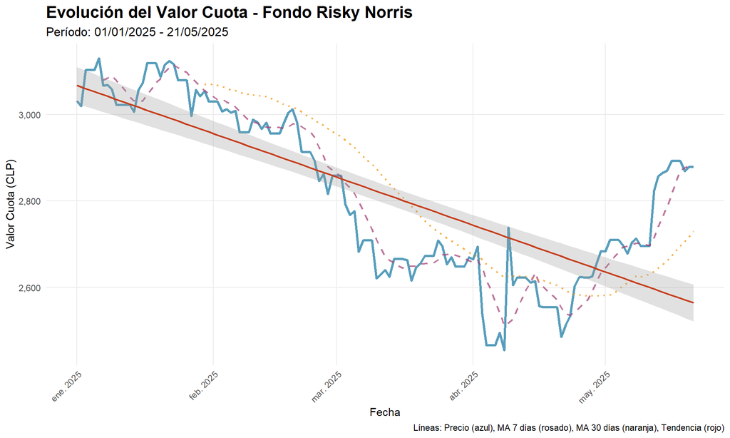

GRÁFICO PRINCIPAL: Evolución del valor cuota con indicadores técnicos. Línea azul = precio diario, línea rosada = media móvil 7 días, línea naranja = media móvil 30 días, línea roja = tendencia general

```r
ggplot(df_analysis, aes(x = date, y = price)) +
  geom_line(color = "#2E86AB", size = 1.2, alpha = 0.8) +
  geom_line(
    aes(y = ma_7),
    color = "#A23B72",
    size = 0.8,
    alpha = 0.7,
    linetype = "dashed"
  ) +
  geom_line(
    aes(y = ma_30),
    color = "#F18F01",
    size = 0.8,
    alpha = 0.7,
    linetype = "dotted"
  ) +
  geom_smooth(
    method = "lm",
    color = "#C73E1D",
    size = 0.8,
    alpha = 0.3,
    se = TRUE
  ) +
  scale_y_continuous(labels = scales::comma_format()) +
  scale_x_date(date_breaks = "1 month", date_labels = "%b %Y") +
  labs(
    title = "Evolución del Valor Cuota - Fondo Risky Norris",
    subtitle = paste0(
      "Período: ",
      format(as.Date(start_date), "%d/%m/%Y"),
      " - ",
      format(as.Date(end_date), "%d/%m/%Y")
    ),
    x = "Fecha",
    y = "Valor Cuota (CLP)",
    caption = "Líneas: Precio (azul), MA 7 días (rosado), MA 30 días (naranja), Tendencia (rojo)"
  ) +
  theme_minimal() +
  theme(
    plot.title = element_text(size = 16, face = "bold"),
    plot.subtitle = element_text(size = 12),
    axis.text.x = element_text(angle = 45, hjust = 1),
    panel.grid.minor = element_blank()
  )
```

## 2. Análisis de Retornos

### 2.1 Retornos Diarios

**DESCRIPCIÓN PARA IA:** Gráfico de barras que muestra los retornos diarios del fondo. Barras verdes indican días con retornos positivos, barras rojas días con retornos negativos. Permite identificar volatilidad, clusters de volatilidad y días con movimientos excepcionales.

**Código**

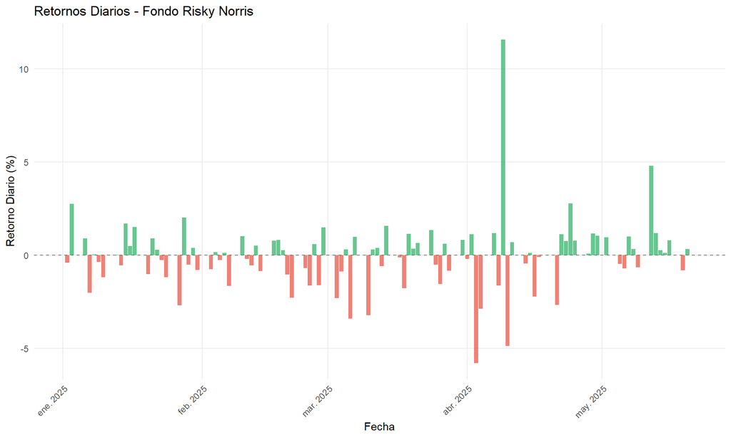

RETORNOS DIARIOS: Barras verdes = días positivos, barras rojas = días negativos. Permite identificar períodos de alta volatilidad y movimientos excepcionales

```r
ggplot(df_analysis, aes(x = date, y = daily_return)) +
  geom_hline(yintercept = 0, color = "gray50", linetype = "dashed") +
  geom_col(aes(fill = daily_return > 0), alpha = 0.7) +
  scale_fill_manual(values = c("TRUE" = "#27AE60", "FALSE" = "#E74C3C")) +
  scale_x_date(date_breaks = "1 month", date_labels = "%b %Y") +
  labs(
    title = "Retornos Diarios - Fondo Risky Norris",
    x = "Fecha",
    y = "Retorno Diario (%)"
  ) +
  theme_minimal() +
  theme(
    legend.position = "none",
    axis.text.x = element_text(angle = 45, hjust = 1),
    panel.grid.minor = element_blank()
  )
```

### 2.2 Retorno Acumulado

**DESCRIPCIÓN PARA IA:** Muestra la evolución del retorno acumulado del fondo desde el inicio del período. Permite evaluar la performance total y identificar períodos de ganancia o pérdida sostenida.

**Código**

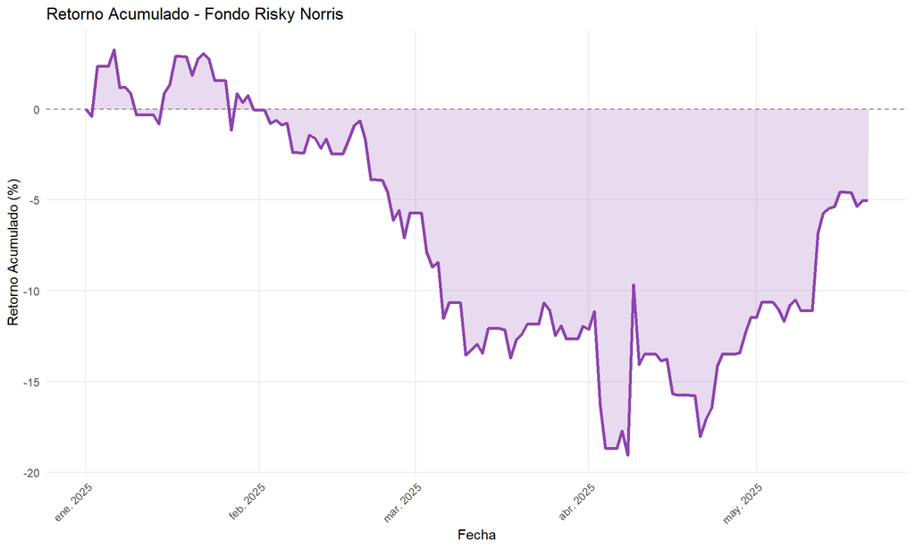

RETORNO ACUMULADO: Evolución de la performance total del fondo desde el inicio del período de análisis

```r
ggplot(df_analysis, aes(x = date, y = cumulative_return)) +
  geom_hline(yintercept = 0, color = "gray50", linetype = "dashed") +
  geom_line(color = "#8E44AD", size = 1.2) +
  geom_area(alpha = 0.2, fill = "#8E44AD") +
  scale_x_date(date_breaks = "1 month", date_labels = "%b %Y") +
  labs(
    title = "Retorno Acumulado - Fondo Risky Norris",
    x = "Fecha",
    y = "Retorno Acumulado (%)"
  ) +
  theme_minimal() +
  theme(
    axis.text.x = element_text(angle = 45, hjust = 1),
    panel.grid.minor = element_blank()
  )
```

## 3. Análisis de Volatilidad

### 3.1 Distribución de Retornos

**DESCRIPCIÓN PARA IA:** Histograma que muestra la distribución de los retornos diarios. La línea naranja indica la media de retornos. Permite evaluar la simetría de la distribución, identificar sesgos y evaluar la normalidad de los retornos.

**Código**

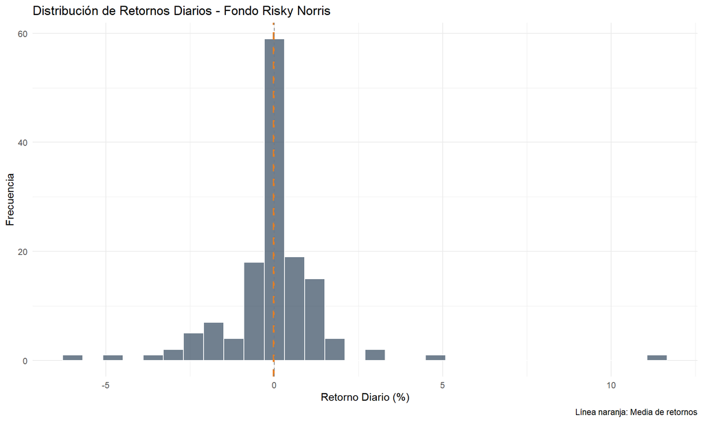

DISTRIBUCIÓN DE RETORNOS: Histograma de retornos diarios. Línea naranja = media. Permite evaluar simetría, sesgos y normalidad de los retornos

```r
ggplot(df_analysis, aes(x = daily_return)) +
  geom_histogram(bins = 30, fill = "#34495E", alpha = 0.7, color = "white") +
  geom_vline(
    xintercept = avg_daily_return,
    color = "#E67E22",
    size = 1,
    linetype = "dashed"
  ) +
  geom_vline(xintercept = 0, color = "gray50", linetype = "dashed") +
  labs(
    title = "Distribución de Retornos Diarios - Fondo Risky Norris",
    x = "Retorno Diario (%)",
    y = "Frecuencia",
    caption = "Línea naranja: Media de retornos"
  ) +
  theme_minimal()
```

### 3.2 Volatilidad Móvil

**DESCRIPCIÓN PARA IA:** Muestra la evolución de la volatilidad móvil de 7 días a lo largo del tiempo. Permite identificar períodos de alta y baja volatilidad, y tendencias en el riesgo del fondo.

**Código**

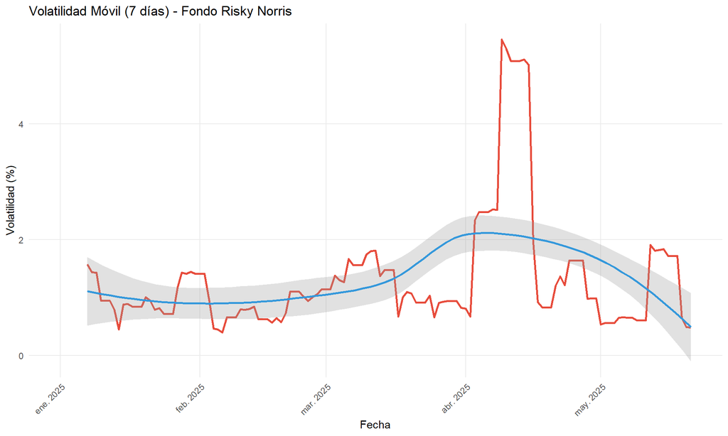

VOLATILIDAD MÓVIL: Evolución de la volatilidad de 7 días. Identifica períodos de alta/baja volatilidad y tendencias en el riesgo

```r
ggplot(df_analysis, aes(x = date, y = volatility_7d)) +
  geom_line(color = "#E74C3C", size = 1) +
  geom_smooth(method = "loess", color = "#3498DB", alpha = 0.3) +
  scale_x_date(date_breaks = "1 month", date_labels = "%b %Y") +
  labs(
    title = "Volatilidad Móvil (7 días) - Fondo Risky Norris",
    x = "Fecha",
    y = "Volatilidad (%)"
  ) +
  theme_minimal() +
  theme(
    axis.text.x = element_text(angle = 45, hjust = 1),
    panel.grid.minor = element_blank()
  )
```

## 4. Métricas Clave

**Código**

```r
# Crear tabla de métricas
metrics_table <- data.frame(
  Métrica = c(
    "Valor Inicial (CLP)",
    "Valor Final (CLP)",
    "Retorno Total (%)",
    "Retorno Promedio Diario (%)",
    "Volatilidad Diaria (%)",
    "Volatilidad Anualizada (%)",
    "Ratio Sharpe Aproximado",
    "Máximo Drawdown (%)",
    "Tendencia General",
    "Cambio Promedio Mensual (CLP)",
    "Días con Movimientos >2%",
    "Mejor Día (%)",
    "Peor Día (%)"
  ),
  Valor = c(
    format(round(start_price), big.mark = ","),
    format(round(end_price), big.mark = ","),
    sprintf("%.2f", total_return),
    sprintf("%.3f", avg_daily_return),
    sprintf("%.3f", volatility),
    sprintf("%.2f", current_annual_vol),
    sprintf("%.2f", sharpe_approx),
    sprintf("%.2f", max_drawdown),
    trend_direction,
    sprintf("%.2f", slope_monthly),
    sprintf(
      "%d de %d (%.1f%%)",
      significant_moves,
      nrow(df_analysis),
      significant_moves / nrow(df_analysis) * 100
    ),
    sprintf("%.2f", max(df_analysis$daily_return, na.rm = TRUE)),
    sprintf("%.2f", min(df_analysis$daily_return, na.rm = TRUE))
  )
)

kable(
  metrics_table,
  caption = "Resumen de Métricas Principales - Fondo Risky Norris",
  align = c("l", "r")
)
```

Resumen de Métricas Principales - Fondo Risky Norris

| Métrica | Valor |
| --- | --- |
| Valor Inicial (CLP) | 3,031 |
| Valor Final (CLP) | 2,878 |
| Retorno Total (%) | -5.05 |
| Retorno Promedio Diario (%) | -0.024 |
| Volatilidad Diaria (%) | 1.609 |
| Volatilidad Anualizada (%) | 25.54 |
| Ratio Sharpe Aproximado | -0.24 |
| Máximo Drawdown (%) | -19.04 |
| Tendencia General | BAJISTA |
| Cambio Promedio Mensual (CLP) | -107.87 |
| Días con Movimientos >2% | 16 de 141 (11.3%) |
| Mejor Día (%) | 11.57 |
| Peor Día (%) | -5.78 |

## 5. Evaluación de Riesgo

**Código**

```r
# Evaluación de riesgo basada en volatilidad
risk_description <- case_when(
  current_annual_vol < 15 ~ "BAJA",
  current_annual_vol < 25 ~ "MODERADA-ALTA",
  current_annual_vol < 35 ~ "ALTA",
  TRUE ~ "MUY ALTA"
)

# Crear tabla de evaluación de riesgo
risk_table <- data.frame(
  Aspecto = c(
    "Volatilidad Anualizada (%)",
    "Clasificación de Volatilidad",
    "Días con Movimientos Significativos",
    "Frecuencia de Alta Volatilidad",
    "Ratio Sharpe",
    "Drawdown Máximo (%)"
  ),
  Resultado = c(
    sprintf("%.1f", current_annual_vol),
    risk_description,
    sprintf("%.1f%% del período", significant_moves / nrow(df_analysis) * 100),
    ifelse(
      current_annual_vol > 25,
      "ALTA",
      ifelse(current_annual_vol > 15, "MODERADA", "BAJA")
    ),
    sprintf("%.2f", sharpe_approx),
    sprintf("%.2f", abs(max_drawdown))
  )
)

kable(
  risk_table,
  caption = "Evaluación de Riesgo del Fondo Risky Norris",
  align = c("l", "l")
)
```

Evaluación de Riesgo del Fondo Risky Norris

| Aspecto | Resultado |
| --- | --- |
| Volatilidad Anualizada (%) | 25.5 |
| Clasificación de Volatilidad | ALTA |
| Días con Movimientos Significativos | 11.3% del período |
| Frecuencia de Alta Volatilidad | ALTA |
| Ratio Sharpe | -0.24 |
| Drawdown Máximo (%) | 19.04 |

## 6. Análisis Mensual

**Código**

```r
# Crear tabla de análisis mensual
monthly_summary <- vol_periods %>%
  mutate(
    month_name = format(month, "%b %Y"),
    monthly_vol = round(monthly_vol, 2),
    monthly_return = round(monthly_return, 2)
  ) %>%
  select(
    Mes = month_name,
    `Retorno Mensual (%)` = monthly_return,
    `Volatilidad Mensual (%)` = monthly_vol
  )

kable(
  monthly_summary,
  caption = "Análisis de Performance Mensual - Fondo Risky Norris",
  align = c("l", "r", "r")
)
```

Análisis de Performance Mensual - Fondo Risky Norris

| Mes | Retorno Mensual (%) | Volatilidad Mensual (%) |
| --- | --- | --- |
| ene. 2025 | -0.04 | 1.11 |
| feb. 2025 | -5.66 | 0.87 |
| mar. 2025 | -6.59 | 1.18 |
| abr. 2025 | 0.73 | 2.82 |
| may. 2025 | 7.25 | 1.16 |

## 7. Conclusiones para Análisis

### Resumen de Performance

- **Retorno Total**: -5.05%
- **Tendencia General**: **BAJISTA**
- **Volatilidad**: 25.5% anualizada (**ALTA**)

### Características de Riesgo

- **Ratio Sharpe**: -0.24 (indica baja relación riesgo-retorno)
- **Drawdown Máximo**: 19.04%
- **Días Volátiles**: 11.3% del período

### Perfil del Fondo

El **Fundo Risky Norris** muestra características de alto riesgo con una volatilidad anualizada de 25.5%. La distribución de retornos y los indicadores técnicos sugieren un comportamiento típico de fondos de inversión de renta variable.

*Análisis generado el 22 de mayo de 2025 por Paulo Villarroel*